# Chapter code for Applied Predictive Modeling (Kuhn and Johnson, 2013)

Chapter 11

by Brian Hassett

# Chapter 11 Measuring Performance in Classification Models

This is an implementation of the material in **Chapter 11** of **Applied Predictive Modeling** by Max Kuhn and Kjell Johnson[^1]. In this notebook I have reproduced some of the analysis and plots from the chapter. The authors used the `lattice` package for plotting, but I have reproduced the plots using `ggplot2`.

## Setup:

## 11.1 Class Predictions

A simple softmax transformation function to recreate the calculations on page 248:

```r
softmax_trans <- function(y) {
  p <- exp(y)/sum(exp(y))
  return(p)
}

softmax_trans(c(0.25, 0.76, -0.1)) %>% round(2)
```

```
[1] 0.30 0.49 0.21
```

### Well-Calibrated Probabilities

Generate the data required for the analysis and plots in this section:

```r
# Simulate some two class data with two predictors
set.seed(975)
training <- quadBoundaryFunc(500)
testing <- quadBoundaryFunc(1000)
testing$class2 <- ifelse(testing$class == "Class1", 1, 0)
testing$ID <- 1:nrow(testing)

# Fit models
qdaFit <- qda(class ~ X1 + X2, data = training)
rfFit <- randomForest(class ~ X1 + X2, data = training, ntree = 2000)

# Predict the test set
testing$qda <- predict(qdaFit, testing)$posterior[,1]
testing$rf <- predict(rfFit, testing, type = "prob")[,1]

# Generate the calibration analysis
calData1 <- calibration(class ~ qda + rf, data = testing, cuts = 10)
```

### Fig. 11.1 (left panel)

Recreate the left panel of Fig. 11.1 using `ggplot2`:

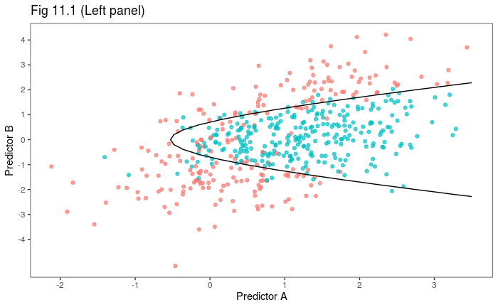

```r
# Ref: https://stackoverflow.com/a/40976865
p1 <- ggplot(training) +
  geom_point(aes(X1, X2, color = class),
             alpha = 0.7, show.legend = F)

boundary <- emdbook::curve3d(-1 - 2*x - 0.2*x^2 + 2*y^2, # when p = 0.5, log(0.5/(1-0.5)) = 0 (page 250)
              xlim = c(-2, 3.5), ylim = c(-4, 4), sys3d="none")
dimnames(boundary$z) <- list(boundary$x, boundary$y)
boundary_melt <- reshape2::melt(boundary)

p1 <- p1 +
  geom_contour(data = boundary_melt,
               aes(x = Var1, y= Var2, z = value), breaks=0,
               colour="black") +
  scale_x_continuous(breaks = -2:3) +
  scale_y_continuous(breaks = -4:4) +
  labs(x = "Predictor A", y = "Predictor B") +
  theme(panel.grid = element_blank())
p1 + ggtitle("Fig 11.1 (Left panel)")
```

### Fig. 11.1 (right panel)

Recreate the right panel of Fig. 11.1 using `ggplot2`:

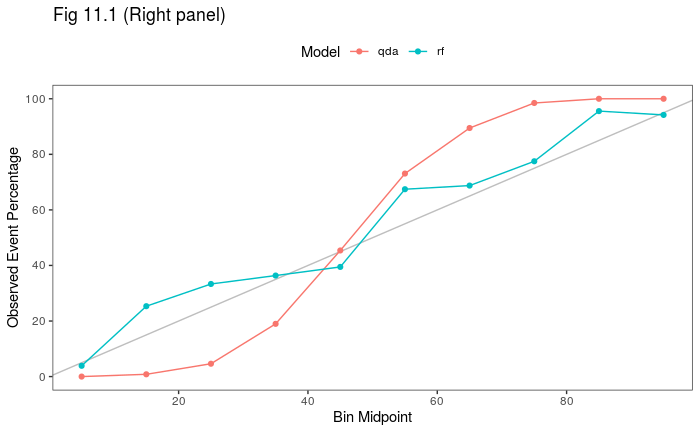

```r
p2 <- ggplot(calData1$data, aes(midpoint, Percent, color = calibModelVar)) +
  geom_abline(color = "grey") +
  geom_point() +
  geom_line() +
  guides(color = guide_legend(title = "Model")) +
  scale_x_continuous(breaks = seq(0, 100, 20)) +
  scale_y_continuous(breaks = seq(0, 100, 20)) +
  labs(x = "Bin Midpoint", y = "Observed Event Percentage") +
  theme(legend.position = "top",
        panel.grid = element_blank())
p2 + ggtitle("Fig 11.1 (Right panel)")
```

### Fig 11.1

Combine both into one:

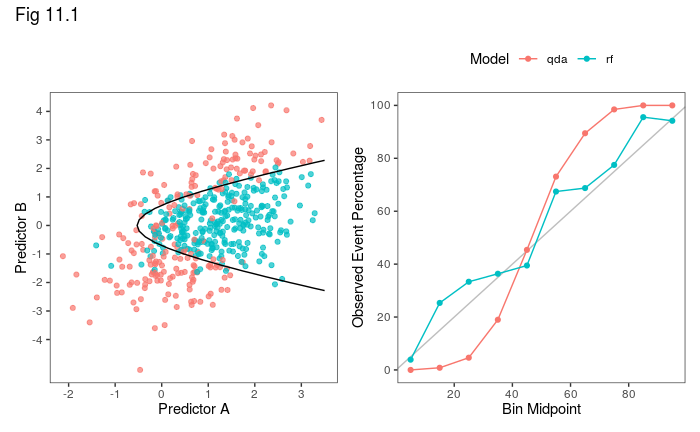

```r
p1 + p2 + plot_annotation(title = "Fig 11.1")
```

### Fig. 11.2:

Generate the recalibrated versions:

```r
# To calibrate the data, treat the probabilities as inputs into the model:
trainProbs <- training
trainProbs$qda <- predict(qdaFit)$posterior[,1]

# These models take the probabilities as inputs and, based on the
# true class, re-calibrate them.
nbCal <- NaiveBayes(class ~ qda, data = trainProbs, usekernel = TRUE)

# We use relevel() here because glm() models the probability of the second factor level:
lrCal <- glm(relevel(class, "Class2") ~ qda, data = trainProbs, family = binomial)

# Now re-predict the test set using the modified class probability estimates:
testing$qda2 <- predict(nbCal, testing[, "qda", drop = FALSE])$posterior[,1]
testing$qda3 <- predict(lrCal, testing[, "qda", drop = FALSE], type = "response")


# Manipulate the data a bit for pretty plotting
simulatedProbs <- testing[, c("class", "rf", "qda3")]
names(simulatedProbs) <- c("TrueClass", "RandomForestProb", "QDACalibrated")
simulatedProbs$RandomForestClass <-  predict(rfFit, testing)

calData2 <- calibration(class ~ qda + qda2 + qda3, data = testing)
calData2$data$calibModelVar <- as.character(calData2$data$calibModelVar)
calData2$data$calibModelVar <- ifelse(calData2$data$calibModelVar == "qda",
                                      "QDA",
                                      calData2$data$calibModelVar)
calData2$data$calibModelVar <- ifelse(calData2$data$calibModelVar == "qda2",
                                      "Bayesian Calibration",
                                      calData2$data$calibModelVar)

calData2$data$calibModelVar <- ifelse(calData2$data$calibModelVar == "qda3",
                                      "Sigmoidal Calibration",
                                      calData2$data$calibModelVar)

calData2$data$calibModelVar <- factor(calData2$data$calibModelVar,
                                      levels = c("QDA",
                                                 "Bayesian Calibration",
                                                 "Sigmoidal Calibration"))
```

Recreate Fig. 11.2 in `ggplot2`:

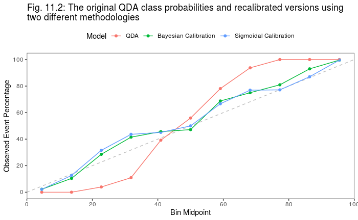

```r
ggplot(calData2$data, aes(midpoint, Percent, color = calibModelVar)) +
  geom_abline(color = "grey", linetype = "dashed") +
  geom_point() +
  geom_line() +
  guides(color = guide_legend(title = "Model")) +
  scale_x_continuous(breaks = seq(0, 100, 20)) +
  scale_y_continuous(breaks = seq(0, 100, 20)) +
  labs(x = "Bin Midpoint", y = "Observed Event Percentage",
       title = str_wrap("Fig. 11.2: The original QDA class probabilities and recalibrated versions using two different methodologies")) +
  theme(legend.position = "top",
        panel.grid = element_blank())
```

### Presenting Class Probabilities

Generate the model using the German credit data:

```r
# Recreate the model used in the over-fitting chapter
data(GermanCredit)

# First, remove near-zero variance predictors then get rid of a few predictors
# that duplicate values. For example, there are two possible values for the
# housing variable: "Rent", "Own" and "ForFree". So that we don't have linear
# dependencies, we get rid of one of the levels (e.g. "ForFree")

GermanCredit <- GermanCredit[, -nearZeroVar(GermanCredit)]
GermanCredit$CheckingAccountStatus.lt.0 <- NULL
GermanCredit$SavingsAccountBonds.lt.100 <- NULL
GermanCredit$EmploymentDuration.lt.1 <- NULL
GermanCredit$EmploymentDuration.Unemployed <- NULL
GermanCredit$Personal.Male.Married.Widowed <- NULL
GermanCredit$Property.Unknown <- NULL
GermanCredit$Housing.ForFree <- NULL

# Split the data into training (80%) and test sets (20%):
set.seed(100)
inTrain <- createDataPartition(GermanCredit$credit_risk, p = .8)[[1]] # changed `$class` to `$credit_risk`
GermanCreditTrain <- GermanCredit[ inTrain, ]
GermanCreditTest  <- GermanCredit[-inTrain, ]

set.seed(1056)
logisticReg <- train(credit_risk ~ ., # changed `class` to `credit_risk`
                     data = GermanCreditTrain,
                     method = "glm",
                     trControl = trainControl(method = "repeatedcv",
                                              repeats = 5))
logisticReg
```

```
Generalized Linear Model

800 samples
 19 predictor
  2 classes: 'good', 'bad'

No pre-processing
Resampling: Cross-Validated (10 fold, repeated 5 times)
Summary of sample sizes: 720, 720, 720, 720, 720, 720, ...
Resampling results:

  Accuracy  Kappa
  0.7542    0.3818
```

### Fig. 11.3 (Top panel)

Recreate the top panel of Fig. 11.3:

```r
# Predict the test set:
creditResults <- data.frame(obs = GermanCreditTest$credit_risk)
creditResults$prob <- predict(logisticReg, GermanCreditTest, type = "prob")[, "bad"] # changed `Bad` to `bad`
```

```
prediction from a rank-deficient fit may be misleading
```

```r
creditResults$pred <- predict(logisticReg, GermanCreditTest)
```

```
prediction from a rank-deficient fit may be misleading
```

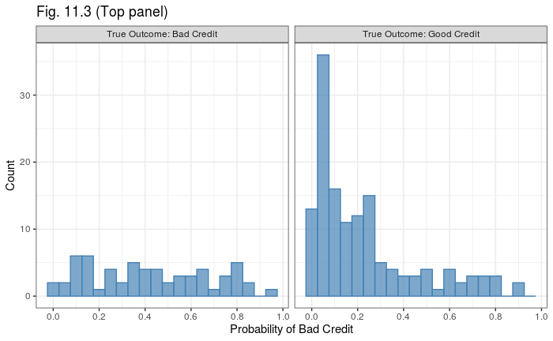

```r
creditResults$Label <- ifelse(creditResults$obs == "bad", # changed `Bad` to `bad`
                              "True Outcome: Bad Credit",
                              "True Outcome: Good Credit")

# Plot histogram:
ggplot(creditResults) +
  geom_histogram(aes(prob), binwidth = 0.05,
                 fill = "steelblue", color = "steelblue", alpha = 0.7) +
  scale_x_continuous(breaks = seq(0, 1, 0.2)) +
  labs(x = "Probability of Bad Credit", y = "Count",
       title = "Fig. 11.3 (Top panel)") +
  facet_wrap(~Label)
```

### Fig 11.3 (Bottom)

Recreate the bottom panel of Fig. 11.3:

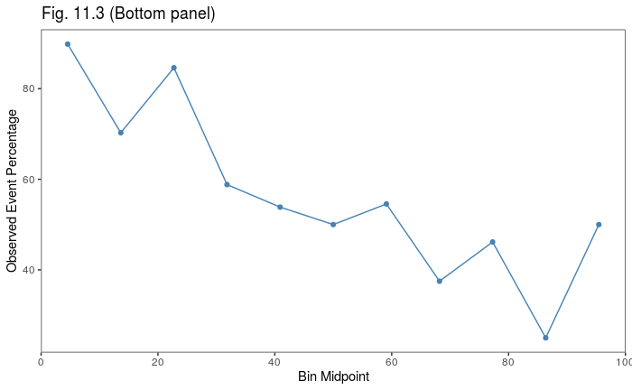

```r
creditCalib <- calibration(obs ~ prob, data = creditResults)
ggplot(creditCalib$data,
       aes(midpoint, Percent)) +
  geom_point(color = "steelblue") +
  geom_line(color = "steelblue") +
  scale_x_continuous(breaks = seq(0, 100, 20)) +
  scale_y_continuous(breaks = seq(0, 100, 20)) +
  labs(x = "Bin Midpoint", y = "Observed Event Percentage",
       title = "Fig. 11.3 (Bottom panel)") +
  theme(panel.grid = element_blank())
```

This plot is different to the authors’. This may be due to differences in the training/test splits. I will need to revisit this and investigate.

## 11.2 Evaluating Predicted Classes

In this section I do a rough reproduction of the confusion matrix and various metrics discussed in the chapter.

Test set confusion matrix for the logistic regression model training with the credit scoring data:

```r
# Create the confusion matrix from the test set:
confusion_mat <- confusionMatrix(data = creditResults$pred,
                reference = creditResults$obs)
confusion_mat
```

```
Confusion Matrix and Statistics

          Reference
Prediction good bad
      good  120  37
      bad    20  23

               Accuracy : 0.715
                 95% CI : (0.647, 0.776)
    No Information Rate : 0.7
    P-Value [Acc > NIR] : 0.3532

                  Kappa : 0.262

 Mcnemar's Test P-Value : 0.0341

            Sensitivity : 0.857
            Specificity : 0.383
         Pos Pred Value : 0.764
         Neg Pred Value : 0.535
             Prevalence : 0.700
         Detection Rate : 0.600
   Detection Prevalence : 0.785
      Balanced Accuracy : 0.620

       'Positive' Class : good
```

The above table and metrics are calculated using the function `caret::confusionMatrix()`. Once the confusion matrix is obtained, all of these metrics can be calculated manually. The below code is a rough guide to manually calculating each value:

```r
# Obtain the actual confusion matrix:
tbl <- confusion_mat$table

# Accuracy:
(tbl %>% diag(.) %>% sum()) / sum(tbl)
```

```
[1] 0.715
```

```r
# No Information Rate (number of `good`s divide by total):
sum(tbl[, 1])/sum(tbl)
```

```
[1] 0.7
```

```r
# P-value:
# The p-value is calculated using a binomial test (I got this code from the source code for caret: https://github.com/topepo/caret/blob/master/pkg/caret/R/confusionMatrix.R)
test1 <- binom.test(sum(diag(tbl)),
                    sum(tbl),
                    p = max(apply(tbl, 2, sum)/sum(tbl)),
                    alternative = "greater")
test1$p.value
```

```
[1] 0.3532
```

```r
# The confidence interval produced by the above test is not the same as the output from confusionMatrix().
# Instead this is calculated using the below code (taken from the source code).
# The difference is that the hypothesis test uses p = 0.7 in the call to binom.test() whereas the CI uses the default p = 0.5:
binom.test(sum(diag(tbl)), sum(tbl))$conf.int[c(1, 2)]
```

```
[1] 0.6471 0.7764
```

```r
# Mcnemar's Test p-value:
mcnemar.test(x = creditResults$pred, y = creditResults$obs)$p.value %>% round(4)
```

```
[1] 0.0341
```

The rest of the values (Sensitivity, Specificity) can be calculated using the formulas in the help page for `confusionMatrix()`:

```r
A <- tbl[1, 1]
B <- tbl[1, 2]
C <- tbl[2, 1]
D <- tbl[2, 2]
beta <- 1 # for calculating F1 below

sensitivity  <-  A/(A+C)
specificity <- D/(B+D)
prevalence <- (A+C)/(A+B+C+D)
PPV <- (sensitivity * prevalence)/((sensitivity*prevalence) + ((1-specificity)*(1-prevalence)))
NPV <- (specificity * (1-prevalence))/(((1-sensitivity)*prevalence) + ((specificity)*(1-prevalence)))
Detection_Rate <- A/(A+B+C+D)
Detection_Prevalence <- (A+B)/(A+B+C+D)
Balanced_Accuracy <- (sensitivity+specificity)/2
precision <- A/(A+B)
recall <- A/(A+C)
F1 <- (1+beta^2)*precision*recall/((beta^2 * precision)+recall)

metrics_list <- c(sensitivity, specificity, prevalence, PPV, NPV, Detection_Rate, Detection_Prevalence, Balanced_Accuracy, precision, recall , F1)
```

Compare the two methods to show they are in agreement:

```r
M <- matrix(c(metrics_list[c(1, 2, 4, 5, 9, 10, 11, 3, 6, 7, 8)], confusion_mat$byClass),
       ncol = 2, byrow = F)
dimnames(M) <- list(names(confusion_mat$byClass), c("manual", "caret"))
M
```

```
                     manual  caret
Sensitivity          0.8571 0.8571
Specificity          0.3833 0.3833
Pos Pred Value       0.7643 0.7643
Neg Pred Value       0.5349 0.5349
Precision            0.7643 0.7643
Recall               0.8571 0.8571
F1                   0.8081 0.8081
Prevalence           0.7000 0.7000
Detection Rate       0.6000 0.6000
Detection Prevalence 0.7850 0.7850
Balanced Accuracy    0.6202 0.6202
```

Calculating `kappa`: according to the source code the `e1071::classAgreement()` function is used to calculate this:

```r
e1071::classAgreement(tbl)
```

```
$diag
[1] 0.715

$kappa
[1] 0.2617

$rand
[1] 0.5904

$crand
[1] 0.1376
```

Manually calculate `kappa` using the source code from the `e1071::classAgreement()` function (see https://github.com/cran/e1071/blob/master/R/matchClasses.R for source code):

```r
n <- sum(tbl)
ni <- apply(tbl, 1, sum)
nj <- apply(tbl, 2, sum)
lev <- intersect (colnames (tbl), rownames(tbl))
p0 <- sum(diag(tbl[lev, lev]))/n # O
pc <- sum(ni[lev] * nj[lev])/n^2 # E
kappa = (p0 - pc)/(1 - pc) # (O - E)/(1 - E)
kappa
```

```
[1] 0.2617
```

### Table 11.2

Test set confusion matrix for the logistic regression model training with the credit scoring data :

```r
tbl2 <- matrix(c(24, 10, 36, 130), nrow = 2, byrow = 2)
tbl2
```

```
     [,1] [,2]
[1,]   24   10
[2,]   36  130
```

```r
A <- tbl2[1, 1]
B <- tbl2[1, 2]
C <- tbl2[2, 1]
D <- tbl2[2, 2]
(B + D)/(sum(tbl2)) # NIR
```

```
[1] 0.7
```

```r
(A + D)/sum(tbl2) # accuracy
```

```
[1] 0.77
```

```r
A/(A + C) # sensitivity
```

```
[1] 0.4
```

```r
D/(B + D) # specificity
```

```
[1] 0.9286
```

### Fig 11.5 (top panel)

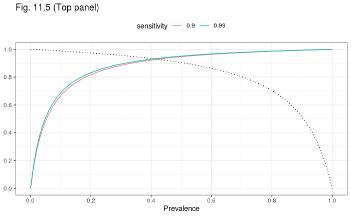

```r
prevalence_curve <- expand_grid(
  prevalence = seq(0, 1, len = 100),
  sensitivity = c(0.9, 0.99),
  specificity = 0.95
) %>%
  mutate(PPV = (sensitivity * prevalence)/((sensitivity * prevalence) + ((1 - specificity) * (1 - prevalence))),
         NPV = (specificity * (1 - prevalence))/((prevalence * (1 - sensitivity)) + (specificity * (1 - prevalence))),
         sensitivity = factor(sensitivity))
ggplot(prevalence_curve) +
  geom_line(aes(prevalence, PPV, group = sensitivity, color = sensitivity)) +
  geom_line(data = filter(prevalence_curve, sensitivity == 0.9),
            aes(prevalence, NPV),
            color = "black", linetype = "dotted") +
  scale_x_continuous(breaks = seq(0, 1, by = 0.2)) +
  scale_y_continuous(breaks = seq(0, 1, by = 0.2)) +
  labs(x = "Prevalence", y = NULL, title = "Fig. 11.5 (Top panel)") +
  theme(legend.position = "top")
```

### Fig 11.5 (bottom panel)

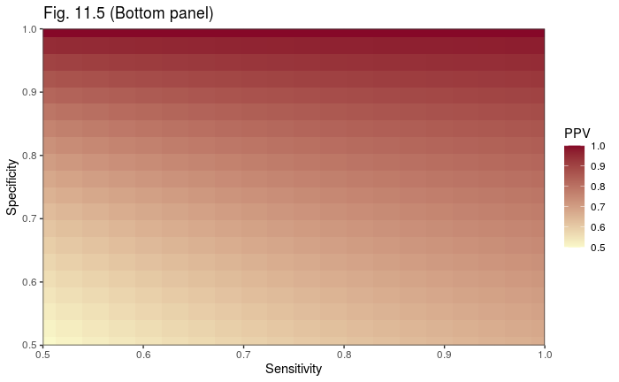

```r
n <- 20
expand_grid(
  prevalence = 0.5,
  sensitivity = seq(0.5, 1, len = n),
  specificity = seq(0.5, 1, length = n)
) %>%
  mutate(PPV = (sensitivity * prevalence)/((sensitivity * prevalence) + ((1 - specificity) * (1 - prevalence)))) %>%
  #mutate(PPV = sensitivity/(sensitivity * (1 - specificity))) %>% # not sure why this doesn't work
  ggplot() +
  geom_tile(aes(sensitivity, specificity, fill = PPV)) +
  scale_fill_gradient(low = "#FAF9CA", high = "#860828") +
  labs(x = "Sensitivity", y = "Specificity", title = "Fig. 11.5 (Bottom panel)") +
  coord_cartesian(xlim = c(0.5, 1), ylim = c(0.5, 1), expand = FALSE)
```

### Non-Accuracy-Based Criteria

This sections reproduces some of the calculations from the chapter.

### Table 11.4

```r
tbl4 <- matrix(c(1500, 1000, 500, 17000), byrow = T, nrow = 2)
tbl4
```

```
     [,1]  [,2]
[1,] 1500  1000
[2,]  500 17000
```

Response rate = 10%; sensitivity = 75%; specificity = 94.4%:

```r
sum(tbl4[ , 1])/sum(tbl4) # response rate
```

```
[1] 0.1
```

```r
tbl4[1, 1]/sum(tbl4[ , 1]) # sensitivity
```

```
[1] 0.75
```

```r
tbl4[2, 2]/sum(tbl4[ , 2]) # specificity
```

```
[1] 0.9444
```

Calculate profit for the left part of Table 11.4:

```r
n <- 20000
TP <- 1500
FP <- 1000
FN <- 500
profit <- 26.4*TP - 2*FP - 28.4*FN
profit
```

```
[1] 23400
```

```r
profit/n
```

```
[1] 1.17
```

Change specificity to 100% (this is equivalent to taking the value form cell (1, 2) and adding them to cell (2, 2):

```r
n <- 20000
TP <- 1500
FP <- 0
FN <- 500
profit <- 26.4*TP - 2*FP - 28.4*FN
profit
```

```
[1] 25400
```

```r
profit/n
```

```
[1] 1.27
```

Calculate profit for the right part of Table 11.4 (mass mailing):

```r
TP <- 2000
FP <- 18000
FN <- 0
profit <- 26.4*TP - 2*FP - 28.4*FN
profit
```

```
[1] 16800
```

```r
profit/n
```

```
[1] 0.84
```

## 11.3 Evaluating Class Probabilities

### Receiver Operating Characteristic (ROC) Curves

The `yardstick` package can be used to generate data for an ROC curve. The plot can easily be made using `autoplot()`:

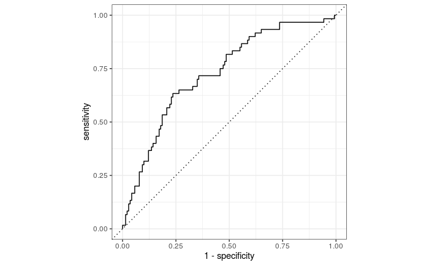

```r
yardstick::roc_curve(data = creditResults, obs, prob, event_level = "second") %>%
  autoplot()
```

### Lift Charts

The `yardstick` package can be used to generate data for a lift chart (referred to as a gain curve). The plot can easily be made using `autoplot()`:

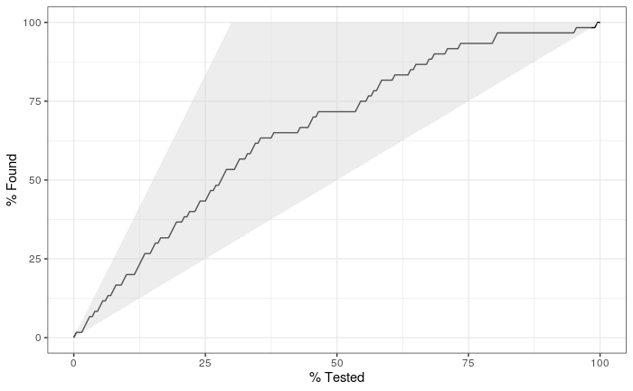

```r
yardstick::gain_curve(data = creditResults, obs, prob, event_level = "second") %>%
  autoplot()
```